# Data Science Capstone Milestone Report - Exploratory Analysis

Timothy M. Rodriguez

Sunday, July 12, 2015

## Summary

In this milestone we are going to first take an initial look at the data to get a better understanding of it and how to work with it. The data set is [HC Corpora](http://www.corpora.heliohost.org/). It is a set of text scraped from the internet in various languages. We will be using the tm R package to due some exploratory analysis of the English data.

## Exploratory Analysis

First, we load the necessary packages and data.

```r
require.or.install <- function(package.name) {
  if (!require(package.name, character.only=TRUE)) {
    install.packages(package.name, dep=TRUE)
    if (!require(package.name, character.only=TRUE)) {
      stop(paste("Could not install package ", package.name))
    }
  }
}

download.if.not.present <- function(url, file.name) {
  if (!file.exists(file.name)) {
    download.file(url, file.name)
  }
}

unzip.if.not.present <- function(zip.file.name, file.name) {
  if (!file.exists(file.name)) {
    unzip(zip.file.name, overwrite=TRUE, exdir=file.name)
  }
}

require.or.install("tm")
require.or.install("doParallel")
```

```r
#require.or.install("Rgraphviz")
require.or.install("ggplot2")
require.or.install("slam")
registerDoParallel(makeCluster(detectCores()))

corpus.file.name <- 'corpus'
corpus.zip.name <- paste(corpus.file.name, ".zip")

download.if.not.present("https://d396qusza40orc.cloudfront.net/dsscapstone/dataset/Coursera-SwiftKey.zip", corpus.zip.name)
unzip.if.not.present(corpus.zip.name, corpus.file.name)
```

## Sampling the data

The files are rather large at:

```r
twitter.file.name <- 'corpus/final/en_US/en_US.twitter.txt'
news.file.name <- 'corpus/final/en_US/en_US.news.txt'
blogs.file.name <- 'corpus/final/en_US/en_US.blogs.txt'

sapply(c(twitter.file.name, news.file.name, blogs.file.name), function(file.name) { paste(round(file.info(file.name)$size / 1024^2, digits=2), ' MB')})
```

```
## corpus/final/en_US/en_US.twitter.txt    corpus/final/en_US/en_US.news.txt
##                         "159.36  MB"                         "196.28  MB"
##   corpus/final/en_US/en_US.blogs.txt
##                         "200.42  MB"
```

We’d like to take a smaller sample of the data to work with inititally. For exploratory purposes, let’s start with 60/20/20 split for training/cross validation/test. It’s important to split the data now so that we maintain a pristine test set that we have not considered even in our exploratory analysis.

```r
split.file <- function(file.name, splits) {
  con <- file(file.name)
  lines <- readLines(con)
  print(paste("Found", length(lines), "lines. In file", file.name))
  print("Splitting the file into a training, testing, and cross validation set")
  line.splits <- runif(length(lines))
  sub.file.name <- substr(file.name, 1, nchar(file.name) - 4)
  train.file <- file(paste(sub.file.name, ".train.txt", sep=""), open="at")
  test.file <- file(paste(sub.file.name, ".test.txt", sep=""), open="at")
  cross.file <- file(paste(sub.file.name, ".cross.txt", sep=""), open="at")

  num.train <- 0
  num.cross <- 0
  num.test <- 0

  for (line.index in 1:length(lines)) {
    split <- line.splits[line.index]
    if (split <= splits[1]) {
      writeLines(lines[line.index], train.file)
      num.train <- num.train + 1
    } else if (split <= splits[1] + splits[2]) {
      writeLines(lines[line.index], cross.file)
      num.cross <- num.cross + 1
    } else {
      writeLines(lines[line.index], test.file)
      num.test <- num.test + 1
    }
  }
  close(train.file)
  close(cross.file)
  close(test.file)
  close(con)
  print(paste(num.train, "lines in training set."))
  print(paste(num.cross, "lines in cross validation set."))
  print(paste(num.test, "lines in test set."))

}
```

```r
splits <- c(0.6, 0.2, 0.2)
split.file(twitter.file.name, splits)
```

```
## [1] "Found 2360148 lines. In file corpus/final/en_US/en_US.twitter.txt"
## [1] "Splitting the file into a training, testing, and cross validation set"
## [1] "1414171 lines in training set."
## [1] "473277 lines in cross validation set."
## [1] "472700 lines in test set."
```

```r
split.file(news.file.name, splits)
```

```
## [1] "Found 77259 lines. In file corpus/final/en_US/en_US.news.txt"
## [1] "Splitting the file into a training, testing, and cross validation set"
## [1] "46405 lines in training set."
## [1] "15501 lines in cross validation set."
## [1] "15353 lines in test set."
```

```r
split.file(blogs.file.name, splits)
```

```
## [1] "Found 899288 lines. In file corpus/final/en_US/en_US.blogs.txt"
## [1] "Splitting the file into a training, testing, and cross validation set"
## [1] "540324 lines in training set."
## [1] "179370 lines in cross validation set."
## [1] "179594 lines in test set."
```

## Frequency Analysis

Here we do an frequency analysis on sample of the training set. To reduce the dimensionality of the data we apply a series of transforms to strip non-essential characters, lower case words, stem the text, and remove common words (stop words) as well as profanity.

```r
set.seed(1234)
sample.percent <- 0.001 #limited memory on my machine
twitter.train <- readLines("corpus/final/en_US/en_US.twitter.train.txt")
news.train <- readLines("corpus/final/en_US/en_US.news.train.txt")
blogs.train <- readLines("corpus/final/en_US/en_US.blogs.train.txt")

create.sampled.corpus <- function(training.set, sample.percent) {
  print(paste("Sampling corpus at", sample.percent))
  Corpus(VectorSource(sample(training.set, sample.percent*length(training.set))))
}

corpi <- sapply(list(twitter.train, news.train, blogs.train), create.sampled.corpus, sample.percent)
```

```
## [1] "Sampling corpus at 0.001"
## [1] "Sampling corpus at 0.001"
## [1] "Sampling corpus at 0.001"
```

```r
combined.corpus <- c(corpi[[1]], corpi[[2]], corpi[[3]])

profanity <- readLines("profanity/en_US/profanity.txt")
clean.corpus <- function(corpus) {
  corpus <- tm_map(corpus, stripWhitespace)
  corpus <- tm_map(corpus, removeNumbers)
  corpus <- tm_map(corpus, removePunctuation)
  corpus <- tm_map(corpus, content_transformer(tolower))
  corpus <- tm_map(corpus, removeWords, c(stopwords("english"), profanity))
  corpus <- tm_map(corpus, stemDocument, language = "english")
  corpus
}

cleaned.corpus <- clean.corpus(combined.corpus)
rm(corpi, combined.corpus, twitter.train, news.train, blogs.train)
```

Now that we have a cleaned corpus, let’s do some analysis on frequencies.

```r
dtm <- DocumentTermMatrix(cleaned.corpus)
```

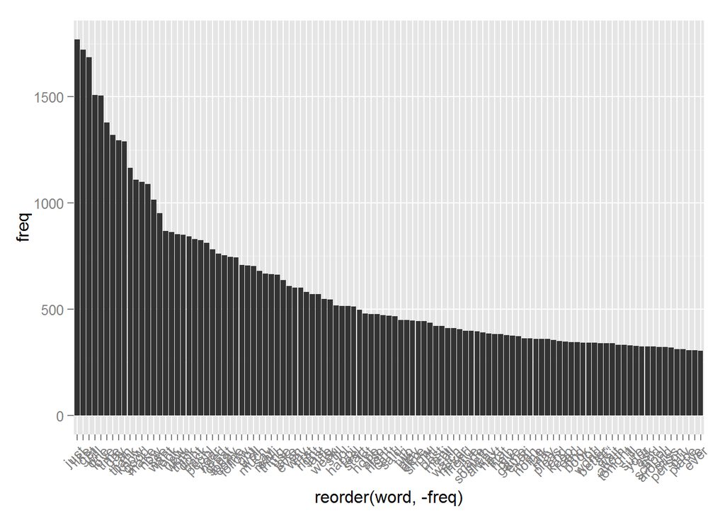

```r
freq <- sort(col_sums(dtm), decreasing=TRUE)
rm(dtm)
word.freq <- data.frame(word=names(freq), freq=freq)
rm(freq)

#dtm <- removeSparseTerms(doc.term.matrix, 0.4)
ggplot(aes(reorder(word, -freq), freq), data=subset(word.freq, freq > 300)) + geom_bar(stat="identity") + theme(axis.text.x=element_text(angle=45, hjust=1))
```

One can see here that the distribution follows a power law and the next word diminishes in frequency quite strongly after the last. This distribution would be much more clear if more data had been indexed. However, only a small sample was able to be taken due to compute resource constraints.

## Summary

Now that there is a text processing pipeline for ingesting and further analyzing the text. This combined sampled corpus can be used for creating a mixed ngram model to predict the next word after a set of words (as is used for predictive text systems such as SwiftKey).